# Homework 4

David Falk

2026-03-06 22:50:56.286539

# Part 0: Importing Data

Import the “participant_level_data_HW4.csv” dataframe supplied on Canvas.

```r
# I completed this homework using the class data dataset for various questions since I completed this homework before the announcement was made. I was told on Slack to leave a note at the top of this homework about this.




participant_data <- read.csv(file.path("data", "participant_level_data_HW4.csv"))
```

# Part 1: Correlations

## Question 1:

Calculate a correlation between “true_recall_proportion” and “false_recall_proportion” from scratch, save the correlation coefficient as “corr_coef” and output this value.

```r
# Pearson is just cov(x,y) / (sd_x * sd_y)

# Get the data
true_recall_values <- participant_data$true_recall_proportion
false_recall_values <- participant_data$false_recall_proportion

# Get means
true_mean <- mean(true_recall_values)
false_mean <- mean(false_recall_values)

# Center data around mean to make cov calculatin easier
true_centered <- true_recall_values - true_mean
false_centered <- false_recall_values - false_mean

# Get standard devs
true_sd <- sd(true_recall_values)
false_sd <- sd(false_recall_values)

# Get covariance
covariance <- sum(true_centered * false_centered) / (length(true_recall_values) - 1)

# Get correlation coefficient
corr_coef <- covariance / (true_sd * false_sd)

# Log the results
cat(sprintf("Correlation Coefficient (True Recall & False Recall): %.6f", corr_coef))
```

```
## Correlation Coefficient (True Recall & False Recall): 0.145126
```

## Question 2:

Let’s see how our continuous variables relate to each other. Create and show a correlation matrix comparing the following values. You can use built-in functions to calculate correlations.

1. True recall proportion
2. False recall proportion
3. VVIQ score

```r
# Get all the columns of interest
relevant_columns <- participant_data[, c("true_recall_proportion",
                                         "false_recall_proportion",
                                         "VVIQ_score")]

# Get the correlation matrix
correlation_matrix <- cor(relevant_columns)

# Log the results
knitr::kable(
  correlation_matrix,
  caption = "Correlation Matrix for True Recall Proportion, False Recall Proportion, and VVIQ Score"
)
```

Correlation Matrix for True Recall Proportion, False Recall Proportion, and VVIQ Score

|  | true_recall_proportion | false_recall_proportion | VVIQ_score |
| --- | --- | --- | --- |
| true_recall_proportion | 1.0000000 | 0.1451256 | 0.0280017 |
| false_recall_proportion | 0.1451256 | 1.0000000 | -0.1211299 |
| VVIQ_score | 0.0280017 | -0.1211299 | 1.0000000 |

*Briefly discuss: Describe the significant relationships you see in this matrix* The diagonal (top left to bottom right) is always exactly 1 because every variable relates perfectly to itself. The matrix is also symmetric across the diagonal as it shows each relationship twice. True recall has a 0.14 relationship with false recall, and this is the strongest correlation between these three variables. VVIQ and true recall have a near zero correlation. VVIQ and false recall share a negative relationship of a similar magnitude as true recall and false recall.

# Part II: Cross Validation

## Question 3:

Perform a hold-out cross-validation of the mixed effects regression model you made in HW 3, Part II, Question 13.

### 3.a:

Set your seed to 2026. Split your data randomly into 80% training / 20% testing. Output the first 10 rows of the test and training datasets.

```r
# Load class data
class_data <- read.csv(file.path("data", "class_data.csv"))

# Standardize variables
class_data$true_recall_proportion_z <- as.numeric(scale(class_data$true_recall_proportion))
class_data$vviq_z <- as.numeric(scale(class_data$VVIQ_score))

# Convert predictors to factors
class_data$encoding_strategy <- as.factor(class_data$encoding_strategy)
class_data$interference_type <- as.factor(class_data$interference_type)
class_data$participant <- as.factor(class_data$participant)

# Get unique participant IDs
participant_ids <- unique(class_data$participant)
num_participants <- length(participant_ids)

# Set the seed
set.seed(2026)

# Number of splits we will do and test/train fractions
num_splits <- 1000
train_fraction <- 0.80
test_fraction <- 0.20

# Get number of participants in training set
num_train_participants <- floor(train_fraction * num_participants)

# Randomly select training participants (we gonna use it as a mask)
train_participants <- sample(participant_ids,
                             size = num_train_participants,
                             replace = FALSE)

# Create training and testing datasets
training_data <- class_data[class_data$participant %in% train_participants, ]
testing_data  <- class_data[!(class_data$participant %in% train_participants), ]

# Output first 10 rows
head(training_data, 10)
```

```
##     X participant interference_type encoding_strategy true_recall_proportion
## 1   1      058217           control  imag_association              0.6222222
## 2   2      058217            verbal  imag_association              0.5111111
## 3   3      058217            visual  imag_association              0.7111111
## 4   4      077402           control  verb_association              0.5777778
## 5   5      077402            verbal  verb_association              0.5555556
## 6   6      077402            visual  verb_association              0.5333333
## 7   7      121818           control       imag_single              0.6000000
## 8   8      121818            verbal       imag_single              0.6444444
## 9   9      121818            visual       imag_single              0.6222222
## 10 10      143678           control  verb_association              0.7333333
##    false_recall_proportion VVIQ_score true_recall_proportion_z     vviq_z
## 1                0.0000000         21               0.55042530 -3.0891645
## 2                0.0000000         21              -0.15109714 -3.0891645
## 3                0.0000000         21               1.11164324 -3.0891645
## 4                0.3333333         64               0.26981632  0.0677696
## 5                0.6666667         64               0.12951183  0.0677696
## 6                0.3333333         64              -0.01079265  0.0677696
## 7                0.3333333         70               0.41012081  0.5082720
## 8                0.3333333         70               0.69072978  0.5082720
## 9                0.0000000         70               0.55042530  0.5082720
## 10               0.3333333         73               1.25194773  0.7285232
```

```r
head(testing_data, 10)
```

```
##     X participant interference_type encoding_strategy true_recall_proportion
## 19 19      453153           control  verb_association              0.4666667
## 20 20      453153            verbal  verb_association              0.4444444
## 21 21      453153            visual  verb_association              0.4222222
## 40 40      662545           control  imag_association              0.5777778
## 41 41      662545            verbal  imag_association              0.4888889
## 42 42      662545            visual  imag_association              0.4444444
## 49 49      746087           control       verb_single              0.5555556
## 50 50      746087            verbal       verb_single              0.3111111
## 51 51      746087            visual       verb_single              0.5555556
## 52 52      781513           control  verb_association              0.5333333
##    false_recall_proportion VVIQ_score true_recall_proportion_z     vviq_z
## 19               0.0000000         74              -0.43170611  0.8019403
## 20               0.0000000         74              -0.57201060  0.8019403
## 21               0.0000000         74              -0.71231509  0.8019403
## 40               0.3333333         58               0.26981632 -0.3727328
## 41               0.3333333         58              -0.29140163 -0.3727328
## 42               0.3333333         58              -0.57201060 -0.3727328
## 49               0.0000000         69               0.12951183  0.4348550
## 50               0.3333333         69              -1.41383752  0.4348550
## 51               0.3333333         69               0.12951183  0.4348550
## 52               0.3333333         69              -0.01079265  0.4348550
```

### 3.b:

Use the training data to determine the best fit model and output the summary.

```r
# Mixed effects model from HW3
mixed_model_training <- lmer(
  true_recall_proportion_z ~
    encoding_strategy +
    interference_type +
    vviq_z +
    (1 | participant),
  data = training_data
)

# Print da results
summary(mixed_model_training)
```

```
## Linear mixed model fit by REML. t-tests use Satterthwaite's method [
## lmerModLmerTest]
## Formula: true_recall_proportion_z ~ encoding_strategy + interference_type +
##     vviq_z + (1 | participant)
##    Data: training_data
##
## REML criterion at convergence: 138.1
##
## Scaled residuals:
##     Min      1Q  Median      3Q     Max
## -1.8390 -0.5995  0.1697  0.5611  1.5459
##
## Random effects:
##  Groups      Name        Variance Std.Dev.
##  participant (Intercept) 0.4848   0.6963
##  Residual                0.3464   0.5886
## Number of obs: 60, groups:  participant, 20
##
## Fixed effects:
##                                    Estimate Std. Error        df t value
## (Intercept)                        0.094220   0.451742 16.829572   0.209
## encoding_strategyimag_single       0.288489   0.521220 14.999999   0.553
## encoding_strategyverb_association  0.277829   0.563149 14.999999   0.493
## encoding_strategyverb_single       0.233310   0.738692 14.999999   0.316
## interference_typeverbal           -0.308670   0.186130 38.000001  -1.658
## interference_typevisual           -0.259563   0.186130 38.000001  -1.395
## vviq_z                             0.007554   0.222539 14.999999   0.034
##                                   Pr(>|t|)
## (Intercept)                          0.837
## encoding_strategyimag_single         0.588
## encoding_strategyverb_association    0.629
## encoding_strategyverb_single         0.756
## interference_typeverbal              0.105
## interference_typevisual              0.171
## vviq_z                               0.973
##
## Correlation of Fixed Effects:
##                     (Intr) encdng_strtgym_ encdng_strtgyvrb_ss
## encdng_strtgym_     -0.770
## encdng_strtgyvrb_ss -0.802  0.650
## encdng_strtgyvrb_sn -0.743  0.592           0.644
## intrfrnc_typvr      -0.206  0.000           0.000
## intrfrnc_typvs      -0.206  0.000           0.000
## vviq_z               0.596 -0.436          -0.553
##                     encdng_strtgyvrb_sn intrfrnc_typvr intrfrnc_typvs
## encdng_strtgym_
## encdng_strtgyvrb_ss
## encdng_strtgyvrb_sn
## intrfrnc_typvr       0.000
## intrfrnc_typvs       0.000               0.500
## vviq_z              -0.643               0.000          0.000
```

### 3.c:

Calculate the model accuracy with the testing data (to measure performance, let’s use r, the correlation between the predictions and true values).

```r
# Get the predicted values
predicted_test_values <- predict(
  mixed_model_training,
  newdata = testing_data,
  allow.new.levels = TRUE
)

# Calculate correlation between predicted and actual values
test_r <- cor(predicted_test_values,
              testing_data$true_recall_proportion_z)

cat(sprintf("Test-set correlation (r): %.6f\n", test_r))
```

```
## Test-set correlation (r): -0.349143
```

### 3.d:

Conduct this cross-validation over 1000 splits. Call the list of resulting model accuracy values cv_r. Set the seed to 2026 before starting your 1000 splits

```r
# Set the seed
set.seed(2026)

# Intialize empty list of proper size
cv_r <- rep(NA, num_splits)

# Iterate number of time we do the split
for (split_index in 1:num_splits) {

  # Get number of training participants
  num_train_participants <- floor(train_fraction * num_participants)

  # Ensure the training sample contains all levels of encoding_strategy
  valid_sample <- FALSE
  while(!valid_sample) {
    # Get the ids for the participants that will be in training set
    train_participants <- sample(participant_ids,
                                 size = num_train_participants,
                                 replace = FALSE)

    # Get training data
    training_data <- class_data[class_data$participant %in% train_participants, ]

    # Check if all 4 strategies are present. If yes, break the while loop.
    if(length(unique(training_data$encoding_strategy)) == 4) {
      valid_sample <- TRUE
    }
  }

  # Get testing data
  testing_data  <- class_data[!(class_data$participant %in% train_participants), ]

  # Train that sucker
  mixed_model_training <- lmer(
    true_recall_proportion_z ~
      encoding_strategy +
      interference_type +
      vviq_z +
      (1 | participant),
    data = training_data
  )

  # Predict them values
  predicted_test_values <- predict(
    mixed_model_training,
    newdata = testing_data,
    allow.new.levels = TRUE
  )

  # Calculate correlation between predicted and actual values
  test_r <- cor(predicted_test_values, testing_data$true_recall_proportion_z)

  # Insert the correlation coefficient in the proper index
  cv_r[split_index] <- test_r
}
```

### 3.e:

Plot a histogram of your model accuracy values and report the mean model accuracy. Also save the mean model accuracy to a variable called `mean_cv_r`.

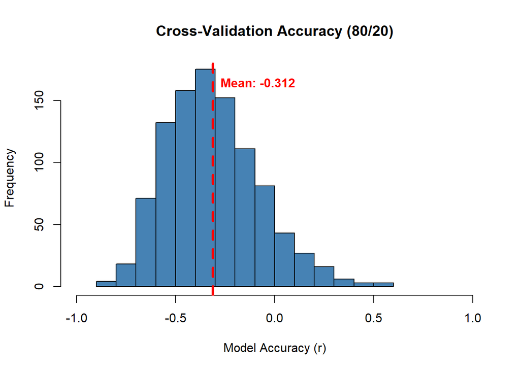

```r
# Get the mean
mean_cv_r <- mean(cv_r)

# Get a little histogram action goin
hist(cv_r,
     main = "Cross-Validation Accuracy (80/20)",
     xlab = "Model Accuracy (r)",
     xlim = c(-1, 1),
     col = "steelblue",
     breaks = 20)

# Put mean on graph
abline(v = mean_cv_r, col = "red", lwd = 3, lty = 2)

# Add legend for mean
text(x = mean_cv_r, y = par("usr")[4] * 0.9,
     labels = paste("Mean:", round(mean_cv_r, 3)),
     pos = 4, col = "red", font = 2)
```

```r
# Print it
cat(sprintf("Mean Cross-Validation Accuracy (80/20): %.6f\n", mean_cv_r))
```

```
## Mean Cross-Validation Accuracy (80/20): -0.311561
```

### 3.f:

Transform the r values with a Fisher Z-transformation (call this cv_z) and conduct a Nadeau-Bengio-corrected t-test of the values versus 0. Save the results in a variable called `cv_t`.

```r
bengio.t.test <- function(results, nperm, ntrain, ntest, alternative="two.sided") {

  m = mean(results)
  var_res = sd(results)**2
  adjusted_var = ((1/nperm) + (ntest/ntrain))*var_res

  t = m / sqrt(adjusted_var)

  df = nperm - 1

  # There are lots of ways to get to p-values from here
  if (alternative=="less") {
    pval = pt(t, df=df)
  } else if (alternative=="greater") {
    pval = 1 - pval
  } else if (alternative=="two.sided") {
    pval = pt(abs(t), df=df, lower.tail=F) * 2
  }

  return(data.frame(t=t, pval=pval, df=df))
}
```

```r
# Z-transform the data
cv_z <- 0.5 * log((1 + cv_r) / (1 - cv_r))

# Do the Nadeau-Bengio t-test
cv_t <- bengio.t.test(
  results = cv_z,
  nperm = num_splits,
  ntrain = train_fraction,
  ntest = test_fraction,
  alternative = "two.sided"
)

# Log the output
knitr::kable(
  cv_t,
  caption = "Nadeau-Bengio Corrected t-test on Fisher Z-transformed CV Accuracy"
)
```

Nadeau-Bengio Corrected t-test on Fisher Z-transformed CV Accuracy

| t | pval | df |
| --- | --- | --- |
| -2.501018 | 0.0125429 | 999 |

### 3.g:

*Briefly discuss: Interpret the resulting t-test and p-value. What does this say about your model?*  
Across 1000 splits the mean predictive accuracy was negative (mean r = −0.311561). After Fisher Z-transforming the r values, the Nadeau-Bengio corrected t-test against 0 was significant (t(999) = -2.501, p = 0.0125). This suggests the model’s out-of-sample predictions are reliably worse than zero association on average, which means poor generalization performance, or depending on if this model is sufficiently predictive in the wrong direction, we could use this model and just take the opposite of what it predicts.

## Question 4:

Conduct a hold-out cross-validation of your model the same as above, but with 50% training and 50% testing. Set the seed to 2026 before starting and then save the model accuracy results in a variable called `cv_r_half`.

```r
## Question 4 (50/50 split)

# Set the seed
set.seed(2026)

# Split sizes
train_fraction_half <- 0.50
test_fraction_half <- 0.50

# Prep a list for output
cv_r_half <- rep(NA, num_splits)

# Iterate over number of splits
for (split_index in 1:num_splits) {

  # Split data
  num_train_participants <- floor(train_fraction_half * num_participants)

  # Keep trying till we get valid sample with all the labels
  valid_sample <- FALSE
  while(!valid_sample) {

    # Get mask to sample for training set
    train_participants <- sample(participant_ids,
                                 size = num_train_participants,
                                 replace = FALSE)

    # Use mask to get training data
    training_data <- class_data[class_data$participant %in% train_participants, ]

    # Check to make sure all labels are present
    if(length(unique(training_data$encoding_strategy)) == 4) {
      valid_sample <- TRUE
    }
  }

  # Get testing data
  testing_data <- class_data[!(class_data$participant %in% train_participants), ]

  # Fit the model
  mixed_model_training <- lmer(
    true_recall_proportion_z ~
      encoding_strategy +
      interference_type +
      vviq_z +
      (1 | participant),
    data = training_data
  )

  # Get predicted value
  predicted_test_values <- predict(
    mixed_model_training,
    newdata = testing_data,
    allow.new.levels = TRUE
  )

  # Add to output list
  cv_r_half[split_index] <- cor(predicted_test_values,
                                testing_data$true_recall_proportion_z)
}

mean_cv_r_half <- mean(cv_r_half)

cat(sprintf("Mean Cross-Validation Accuracy (50/50): %.6f\n", mean_cv_r_half))
```

```
## Mean Cross-Validation Accuracy (50/50): -0.226235
```

### 4.a:

*Briefly discuss: How does the ability of your model to extend to other data change? What does this say about the ideal distribution of training and testing data?*

With a 50/50 train-test split, mean accuracy was still negative but less negative than the 80/20 case (mean r for 50/50 = −0.226235 vs mean r for 80/20 = -0.311561). Changing the split ratio did not fix the generalization issue, but the estimate is slightly closer to zero with 50/50. In general, more training data often helps model learning, but you also need enough test data to get a stable estimate of performance. Since performance is negative here across multiple splits, it seems that the model is likely the issue and not generalizing well.

# Part III: ANOVAs

## Question 5:

This study was designed to be analyzed with an ANOVA (it’s originally designed for a 3-way ANOVA, but let’s start simpler with a 2-way ANOVA). In particular, let’s see how VVIQ score (imagery ability) interacts with encoding depth to impact memory performance. First, we need to make a categorical version of the VVIQ. Create a new column in the dataframe called vviq_level where it is 1 if the participant’s VVIQ score is equal to or higher than the median score across participants, and 0 if it is lower than the median score across participants.

Calculate a 2-way independent samples ANOVA with the DV as true recall performance, and the IVs varying along 2 factors: 1) vviq (categorical, as low / high) and 2) encoding strategy depth (categorical, as deep / shallow).

### 5.a:

Calculate Sum of Squares for vviq from scratch. Call this *SS_vviq* and output this value.

```r
# Get the median so we can split into vviq_level ("high" / "low")
vviq_median <- median(participant_data$VVIQ_score)

# Cast scores to high / low
participant_data$vviq_level <- ifelse(
  participant_data$VVIQ_score >= vviq_median,
  "high",
  "low"
)

# Make sure they are factors bc R likes to act dumb sometimes
participant_data$vviq_level <- as.factor(participant_data$vviq_level)

# Collapse encoding_strategy into deep / shallow
participant_data$strategy_depth <- ifelse(
  participant_data$encoding_strategy %in% c("imag_association", "verb_association"),
  "deep",
  "shallow"
)

participant_data$strategy_depth <- as.factor(participant_data$strategy_depth)

# Grand mean
grand_mean <- mean(participant_data$true_recall_proportion)

# Get means for vviq
vviq_means <- aggregate(true_recall_proportion ~ vviq_level,
                        data = participant_data,
                        mean)

# Get counts for vviq
vviq_counts <- aggregate(true_recall_proportion ~ vviq_level,
                         data = participant_data,
                         length)

# iterate over and get ss vviq
SS_vviq <- 0
for (i in 1:nrow(vviq_means)) {
  SS_vviq <- SS_vviq +
    vviq_counts$true_recall_proportion[i] *
    (vviq_means$true_recall_proportion[i] - grand_mean)^2
}

# Log the outputs
cat(sprintf("SS_vviq: %.6f\n", SS_vviq))
```

```
## SS_vviq: 0.001195
```

### 5.b:

Calculate Sum of Squares for strategy from scratch. Call this *SS_strategy* and output this value.

```r
# Get means for strategy depth
strategy_means <- aggregate(true_recall_proportion ~ strategy_depth,
                            data = participant_data,
                            mean)

# Get counts for strategy depth
strategy_counts <- aggregate(true_recall_proportion ~ strategy_depth,
                             data = participant_data,
                             length)

# Iterate and get ss strategy
SS_strategy <- 0
for (i in 1:nrow(strategy_means)) {
  SS_strategy <- SS_strategy +
    strategy_counts$true_recall_proportion[i] *
    (strategy_means$true_recall_proportion[i] - grand_mean)^2
}

# Print results
cat(sprintf("SS_strategy: %.6f\n", SS_strategy))
```

```
## SS_strategy: 0.007048
```

### 5.c:

Calculate Sum of Squares total from scratch. Call this *SS_total* and output this value.

```r
# Get ss total
SS_total <- sum((participant_data$true_recall_proportion - grand_mean)^2)

# Log results
cat(sprintf("SS_total: %.6f\n", SS_total))
```

```
## SS_total: 0.554086
```

### 5.d:

Calculate Sum of Squares within from scratch. Call this *SS_within* and output this value.

```r
# Get cell level means true recall against vviq and strategy depth
cell_means <- aggregate(true_recall_proportion ~ vviq_level + strategy_depth,
                        data = participant_data,
                        mean)

# iterate and get ss within
SS_within <- 0
for (i in 1:nrow(cell_means)) {

  # current vviq, strategy and mean
  current_vviq <- cell_means$vviq_level[i]
  current_strategy <- cell_means$strategy_depth[i]
  current_mean <- cell_means$true_recall_proportion[i]

  # Get rows with given vviq category and strategy depth
  cell_rows <- participant_data$vviq_level == current_vviq &
    participant_data$strategy_depth == current_strategy

  # Get true recall data for the correct rows
  cell_values <- participant_data$true_recall_proportion[cell_rows]

  # Update SS within
  SS_within <- SS_within + sum((cell_values - current_mean)^2)
}

# Print results
cat(sprintf("SS_within: %.6f\n", SS_within))
```

```
## SS_within: 0.494242
```

## Question 6:

Write code that generates an ANOVA table that uses the format from the HW 4 instructions document, and populate it using your calculations. Calculate MS and F from scratch. The p-values can be calculated with built-in R functions. Output this table.  
(hint: feel free to use knitr::kable)

**For the five cells that have a “–” in the HW instructions, leave these in your dataframe as “NA”s.**

```r
# Number of levels
a_levels <- 2
b_levels <- 2
N_total <- nrow(participant_data)

# Degrees of freedom
df_vviq <- 1
df_strategy <- 1
df_interaction <- 1
df_within <- N_total - 4
df_total <- N_total - 1

# Get interaction SS
SS_interaction <- SS_total - SS_within - SS_vviq - SS_strategy

# Get mean squares
MS_vviq <- SS_vviq / df_vviq
MS_strategy <- SS_strategy / df_strategy
MS_interaction <- SS_interaction / df_interaction
MS_within <- SS_within / df_within

# Get F values
F_vviq <- MS_vviq / MS_within
F_strategy <- MS_strategy / MS_within
F_interaction <- MS_interaction / MS_within

# Get p values
p_vviq <- pf(F_vviq, df_vviq, df_within, lower.tail = FALSE)
p_strategy <- pf(F_strategy, df_strategy, df_within, lower.tail = FALSE)
p_interaction <- pf(F_interaction, df_interaction, df_within, lower.tail = FALSE)

# Make the table
anova_table <- data.frame(
  `Sum of Squares` = c(SS_vviq, SS_strategy, SS_interaction, SS_within, SS_total),
  df = c(df_vviq, df_strategy, df_interaction, df_within, df_total),
  `Mean Square` = c(MS_vviq, MS_strategy, MS_interaction, MS_within, NA),
  F = c(F_vviq, F_strategy, F_interaction, NA, NA),
  p = c(p_vviq, p_strategy, p_interaction, NA, NA),
  row.names = c("VVIQ", "Strategy", "Interaction", "Within", "Total")
)

knitr::kable(
  anova_table,
  digits = 6,
  caption = "2 x 2 Independent Samples ANOVA Table"
)
```

2 x 2 Independent Samples ANOVA Table

|  | Sum.of.Squares | df | Mean.Square | F | p |
| --- | --- | --- | --- | --- | --- |
| VVIQ | 0.001195 | 1 | 0.001195 | 0.077367 | 0.782687 |
| Strategy | 0.007048 | 1 | 0.007048 | 0.456308 | 0.504207 |
| Interaction | 0.051602 | 1 | 0.051602 | 3.340998 | 0.076911 |
| Within | 0.494242 | 32 | 0.015445 | NA | NA |
| Total | 0.554086 | 35 | NA | NA | NA |

## Question 7:

Create a bar graph showing the means of the 4 different conditions (2 VVIQ levels x 2 strategy types), and mark significance for the factors/interactions on this plot.

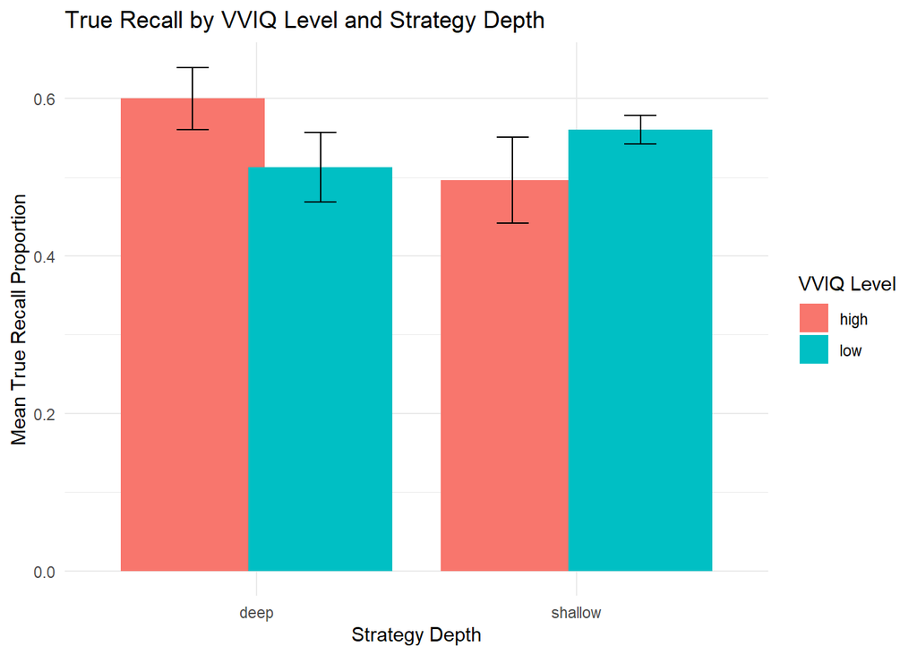

```r
# Get summary stats for each of the 4 cells
cell_summary <- participant_data %>%
  group_by(vviq_level, strategy_depth) %>%
  summarize(
    mean_true_recall = mean(true_recall_proportion),
    se_true_recall = sd(true_recall_proportion) / sqrt(n()),
    .groups = "drop"
  )

# Make bar graph
ggplot(cell_summary,
       aes(x = strategy_depth,
           y = mean_true_recall,
           fill = vviq_level)) +
  geom_bar(stat = "identity",
           position = position_dodge(width = 0.8)) +
  geom_errorbar(aes(ymin = mean_true_recall - se_true_recall,
                    ymax = mean_true_recall + se_true_recall),
                width = 0.2,
                position = position_dodge(width = 0.8)) +
  labs(
    title = "True Recall by VVIQ Level and Strategy Depth",
    x = "Strategy Depth",
    y = "Mean True Recall Proportion",
    fill = "VVIQ Level"
  )
```

```r
# Print significance results so we can reference them on the plot
cat(sprintf("VVIQ effect p-value: %.6f\n", p_vviq))
```

```
## VVIQ effect p-value: 0.782687
```

```r
cat(sprintf("Strategy effect p-value: %.6f\n", p_strategy))
```

```
## Strategy effect p-value: 0.504207
```

```r
cat(sprintf("Interaction p-value: %.6f\n", p_interaction))
```

```
## Interaction p-value: 0.076911
```

## Question 8:

Calculate effect size (partial eta squared) for each factor and the interaction from scratch. Call these: `eta_vviq_level`, `eta_strategy`, and `eta_interaction` and output these values.

```r
# Get partial eta squared values
eta_vviq_level <- SS_vviq / (SS_vviq + SS_within)
eta_strategy <- SS_strategy / (SS_strategy + SS_within)
eta_interaction <- SS_interaction / (SS_interaction + SS_within)

# Log outputs
cat(sprintf("Partial eta^2 (VVIQ): %.6f\n", eta_vviq_level))
```

```
## Partial eta^2 (VVIQ): 0.002412
```

```r
cat(sprintf("Partial eta^2 (Strategy): %.6f\n", eta_strategy))
```

```
## Partial eta^2 (Strategy): 0.014059
```

```r
cat(sprintf("Partial eta^2 (Interaction): %.6f\n", eta_interaction))
```

```
## Partial eta^2 (Interaction): 0.094536
```

## Question 9:

Describe the statistics for each factor, their interaction, and the effect sizes as if for a research paper, referring to this bar graph. Include interpretation of the results.

A 2×2 independent-samples ANOVA was used to examine true recall as a function of VVIQ level (low vs. high) and encoding depth (shallow vs. deep). There was no main effect of VVIQ level (F(1, 32) = 0.077, p = 0.783, eta^2 = 0.002412). There was also no main effect of strategy depth (F(1, 32) = 0.456, p = 0.504, eta^2 = 0.0141). The VVIQ and strategy depth interaction flirted with significance (F(1, 32) = 3.341, p = 0.0769, eta^2 = 0.0945). Given the critical nature of this research and its potential humanitarian impact, we believe that a 5-year 2.7 million dollar grant would be appropriate to collect more data, run further analyses, and do everything in our power to ensure we get this p value below 0.05. As shown in the bar graph, the pattern of means suggests the effect of encoding depth may differ by imagery ability, but the evidence is not strong enough to conclude that there is a reliable interaction at an alpha level of 0.05. With further financial support, our team is confident we can fix this.

## Question 10:

Calculate this ANOVA using R built-in functions to check your numbers.

```r
# Run the built-in ANOVA
anova_builtin <- aov(
  true_recall_proportion ~ vviq_level * strategy_depth,
  data = participant_data
)

# Get anova table
anova_builtin_table <- summary(anova_builtin)[[1]]

# Print the results
knitr::kable(
  anova_builtin_table,
  digits = 6,
  caption = "Built-in 2x2 Independent Samples ANOVA Check"
)
```

Built-in 2x2 Independent Samples ANOVA Check

|  | Df | Sum Sq | Mean Sq | F value | Pr(>F) |
| --- | --- | --- | --- | --- | --- |
| vviq_level | 1 | 0.001195 | 0.001195 | 0.077367 | 0.782687 |
| strategy_depth | 1 | 0.007048 | 0.007048 | 0.456308 | 0.504207 |
| vviq_level:strategy_depth | 1 | 0.051602 | 0.051602 | 3.340998 | 0.076911 |
| Residuals | 32 | 0.494242 | 0.015445 | NA | NA |

## Question 11:

Calculate this ANOVA instead as a within-subjects (repeated measures) ANOVA using R built-in functions. Save the results in a variable called anova_within and display the statistic and p values for each factor and their interaction.

```r
# Get the median
vviq_median_class <- median(class_data$VVIQ_score)

# Split into high/low again
class_data$vviq_level <- ifelse(
  class_data$VVIQ_score >= vviq_median_class,
  "high",
  "low"
)

# Add it as a factor
class_data$vviq_level <- as.factor(class_data$vviq_level)

# Run repeated measures anova w/ interference_type within-subject
anova_within <- aov(
  true_recall_proportion ~
    vviq_level * encoding_strategy * interference_type +
    Error(participant / interference_type),
  data = class_data
)

# Get summary
anova_within_summary <- summary(anova_within)

# Get between-subject table
between_table <- as.data.frame(
  anova_within_summary[["Error: participant"]][[1]]
)

# Get within-subject table
within_table <- as.data.frame(
  anova_within_summary[["Error: participant:interference_type"]][[1]]
)

# Print results
knitr::kable(
  between_table,
  digits = 6,
  caption = "Repeated Measures ANOVA: Between-Subjects Effects"
)
```

Repeated Measures ANOVA: Between-Subjects Effects

|  | Df | Sum Sq | Mean Sq | F value | Pr(>F) |
| --- | --- | --- | --- | --- | --- |
| vviq_level | 1 | 0.007319 | 0.007319 | 0.118594 | 0.734347 |
| encoding_strategy | 3 | 0.045544 | 0.015181 | 0.245998 | 0.863139 |
| vviq_level:encoding_strategy | 2 | 0.289425 | 0.144713 | 2.344931 | 0.122974 |
| Residuals | 19 | 1.172546 | 0.061713 | NA | NA |

```r
knitr::kable(
  within_table,
  digits = 6,
  caption = "Repeated Measures ANOVA: Within-Subjects Effects"
)
```

Repeated Measures ANOVA: Within-Subjects Effects

|  | Df | Sum Sq | Mean Sq | F value | Pr(>F) |
| --- | --- | --- | --- | --- | --- |
| interference_type | 2 | 0.033884 | 0.016942 | 2.339534 | 0.110104 |
| vviq_level:interference_type | 2 | 0.039101 | 0.019550 | 2.699731 | 0.080110 |
| encoding_strategy:interference_type | 6 | 0.065910 | 0.010985 | 1.516919 | 0.198996 |
| vviq_level:encoding_strategy:interference_type | 4 | 0.002713 | 0.000678 | 0.093647 | 0.983890 |
| Residuals | 38 | 0.275182 | 0.007242 | NA | NA |

*Briefly discuss: How do the results change when instead using a repeated measures ANOVA? What is the correct function to use?*

When switching to the repeated-measures ANOVA (with interference type as the within-subject factor), the conclusions are mostly similar in that effects are not statistically significant. For between-subject effects, VVIQ level was not significant (p = 0.734), encoding strategy was not significant (p = 0.863), and their interaction was not significant (p = 0.123).

For within-subject effects, interference type was not significant (p = 0.110), and none of the interactions with interference type were significant (e.g. VVIQ against interference type had a p value of 0.080).

The main difference is that the repeated-measures model accounts for the non-independence of observations from the same participant, which can change error terms and p-values compared to an independent-samples ANOVA. The correct approach is repeated-measures ANOVA using an Error() term in aov() for within-subject factors.

# Part IV: ANOVA as regression

## Question 12:

Write the independent samples ANOVA as a regression model, and report the regression model formula. (Remember that VVIQ and encoding strategy are now categorical, not continuous.)

```r
# Regression form of the 2x2 independent-samples ANOVA
# DV: true_recall_proportion
# Predictors: vviq_level (low/high), strategy_depth (shallow/deep), and their interaction

# Model formula (R):
cat(sprintf("Written like you write it in R\n==============================\n"))
```

```
## Written like you write it in R
## ==============================
```

```r
true_recall_proportion ~ vviq_level * strategy_depth
```

```
## true_recall_proportion ~ vviq_level * strategy_depth
```

```r
# Equivalent written regression equation:
cat(sprintf("\n\nWritten as an equation\n======================\n"))
```

```
##
##
## Written as an equation
## ======================
```

```r
cat(sprintf("Y = β0 + β1*(VVIQ_level) + β2*(Strategy_depth) + β3*(VVIQ_level × Strategy_depth) + error_term"))
```

```
## Y = β0 + β1*(VVIQ_level) + β2*(Strategy_depth) + β3*(VVIQ_level × Strategy_depth) + error_term
```

## Question 13:

Conduct the regression model using R built-in functions. How do the outputs of this model compare to those of the ANOVA?

```r
## Question 13 (Run regression equivalent to ANOVA)

# Fit regression model
anova_regression <- lm(
  true_recall_proportion ~
    vviq_level +
    strategy_depth +
    vviq_level:strategy_depth,
  data = participant_data
)

# Get regression summary
regression_summary <- summary(anova_regression)

# Print coefficient table
knitr::kable(
  as.data.frame(regression_summary$coefficients),
  digits = 6,
  caption = "Regression Coefficients for 2x2 Model"
)
```

Regression Coefficients for 2x2 Model

|  | Estimate | Std. Error | t value | Pr(>\|t\|) |
| --- | --- | --- | --- | --- |
| (Intercept) | 0.600000 | 0.041426 | 14.483642 | 0.000000 |
| vviq_levellow | -0.087243 | 0.058585 | -1.489159 | 0.146236 |
| strategy_depthshallow | -0.103704 | 0.058585 | -1.770133 | 0.086233 |
| vviq_levellow:strategy_depthshallow | 0.151440 | 0.082852 | 1.827840 | 0.076911 |

```r
# Print ANOVA table from regression
regression_anova_table <- anova(anova_regression)

knitr::kable(
  regression_anova_table,
  digits = 6,
  caption = "ANOVA Table from Regression Model"
)
```

ANOVA Table from Regression Model

|  | Df | Sum Sq | Mean Sq | F value | Pr(>F) |
| --- | --- | --- | --- | --- | --- |
| vviq_level | 1 | 0.001195 | 0.001195 | 0.077367 | 0.782687 |
| strategy_depth | 1 | 0.007048 | 0.007048 | 0.456308 | 0.504207 |
| vviq_level:strategy_depth | 1 | 0.051602 | 0.051602 | 3.340998 | 0.076911 |
| Residuals | 32 | 0.494242 | 0.015445 | NA | NA |